# Predicting Depression Severity and How it Affects Normal Functioning

in 2000 NHANES 2021-2023 Participants

Author

Lauren Sapienza

Published

2026-05-06

## R Packages and Setup

```r
knitr::opts_chunk$set(comment = NA)

library(janitor)
library(naniar)
library(conflicted)

library(broom)
library(gt)
library(gtsummary)
library(MASS)
library(mice)
library(mosaic)
library(nhanesA)
library(nnet)
library(rms)
library(rsample)
library(topmodels)
library(yardstick)

library(easystats)
library(tidyverse)

conflicts_prefer(dplyr::filter, dplyr::select, Hmisc::html,
                 base::max, base::min, base::sum,
                 yardstick::rmse, yardstick::mae)

theme_set(theme_bw())
```

# 1 Background

My data are sourced from the 2021-2023 National Health and Nutrition Examination Survey (NHANES)[^1] performed by the National Center for Health Statistics. This is a comprehensive survey that collects health and nutrition information on adults and children in the United States. It involves health exams, laboratory tests, and interviews on around 5000 participants around the United States.

I will be focusing my analysis on the nine-item depression screening called the Patient Health Questionnaire (PHQ-9) that is a part of the interview. I am interested in seeing if a score on the PHQ-9 can be reasonably predicted by other information that is collected during NHANES, and what factors impact functional impairment the most. My predictors were developed to represent depression risk factors or symptoms including difficulty sleeping or over sleeping, unplanned weight changes, a diabetes co-morbidity, and increased alcohol use[^2].

[^1]: NHANES data files for 2021-2023 can be found at https://wwwn.cdc.gov/nchs/nhanes/continuousnhanes/default.aspx?Cycle=2021-2023
[^2]: The depression fact sheet I used to develop my predictors, from the National Institute of Mental Health, can be found here https://www.nimh.nih.gov/health/publications/depression

# 2 Research Questions

## 2.1 Research Question 1

How well can you predict a subject’s score on the PHQ-9 depression screening using their age, sex, average hours of sleep, average minutes of moderate activity, average number of alcoholic drinks consumed, and diabetes diagnosis in a sample of 2000 adults from NHANES 2021-2023?

## 2.2 Research Question 2

What variables have the largest effect size when predicting a subject’s level of ability to function due to depressive symptoms using their age, sex, BMI, and PHQ-9 depression score in a sample of 2000 adults from NHANES 2021-2023?

# 3 Data Ingest and Management

## 3.1 Loading the Raw Data

```r
# alc_raw <- nhanes('ALQ_L') |> tibble()
# saveRDS(alc_raw, "ALQ_L.Rds")

# bmi_raw <- nhanes('BMX_L') |> tibble()
# saveRDS(bmi_raw, "BMX_L.Rds")

# demo_raw <- nhanes('DEMO_L') |> tibble()
# saveRDS(demo_raw, "DEMO_L.Rds")

# diab_raw <- nhanes('DIQ_L') |> tibble()
# saveRDS(diab_raw, "DIQ_L.Rds")

# depr_raw <- nhanes('DPQ_L', translate=FALSE) |> tibble()
# saveRDS(depr_raw, "DPQ_L.Rds")

# active_raw <- nhanes('PAQ_L') |> tibble()
# saveRDS(active_raw, "PAQ_L.Rds")

# sleep_raw <- nhanes('SLQ_L') |> tibble()
# saveRDS(sleep_raw, "SLQ_L.Rds")
```

First, we load all the data files we are using, turn them into tibbles, and save them as .Rds files for easy access.

## 3.2 Cleaning the Data

### 3.2.1 Selecting and Naming the Variables We’ll Use

Here, for each variable, we rename it and select only the variables we need from that data file. We also change any categorical variables into factors.

```r
alc_raw <- readRDS('data/ALQ_L.Rds')

alc_raw <- alc_raw |>
  mutate(avg_alc = ALQ130) |>
  filter(avg_alc < 15) |>
  select(SEQN, avg_alc)
```

For the `avg_alc` variable, we filter to values below 15, as 15 is a stand in for all values greater than 15.

```r
bmi_raw <- readRDS('data/BMX_L.Rds')

bmi_raw <- bmi_raw |>
  mutate(bmi = BMXBMI) |>
  select(SEQN, bmi)
```

```r
demo_raw <- readRDS('data/DEMO_L.Rds')

demo_raw <- demo_raw |>
  mutate(check = factor(RIDSTATR),
         age = RIDAGEYR,
         female = factor(case_when(RIAGENDR == 'Female' ~ 'Yes',
                                   RIAGENDR == 'Male' ~ 'No'))) |>
  select(SEQN, age, check, female)
```

We convert the original `RIAGENDR` variable to become the `female` variable, where ‘Yes’ means the subject is female and ‘No’ means the subject is male.

```r
diab_raw <- readRDS('data/DIQ_L.Rds')

diab_raw <- diab_raw |>
  mutate(diabetes = factor(DIQ010)) |>
  select(SEQN, diabetes)
```

```r
active_raw <- readRDS('data/PAQ_L.Rds')

active_raw <- active_raw |>
  mutate(min_act = PAD800) |>
  select(SEQN, min_act)
```

```r
sleep_raw <- readRDS('data/SLQ_L.Rds')

sleep_raw <- sleep_raw |>
  mutate(avg_sleep = SLD012) |>
  select(SEQN, avg_sleep) |>
  filter(avg_sleep <= 13.5 & avg_sleep >= 3)
```

The `avg_sleep` variable gets filtered to values between 3 and 13.5, as 2 is a stand in for all values less than 3 and 14 is a stand in for all values greater than 13.5.

### 3.2.2 Recoding Missing Values

```r
alc_raw <- alc_raw |>
  replace_with_na_at(.vars = 'avg_alc', condition = ~ .x == 777) |>
  replace_with_na_at(.vars = 'avg_alc', condition = ~ .x == 999)

diab_raw <- diab_raw |>
  replace_with_na_at(.vars = 'diabetes', condition = ~ .x == 'Refused') |>
  replace_with_na_at(.vars = 'diabetes', condition = ~ .x == "Don't know")

active_raw <- active_raw |>
  replace_with_na_at(.vars = 'min_act', condition = ~ .x == 7777) |>
  replace_with_na_at(.vars = 'min_act', condition = ~ .x == 9999)
```

Here we re-code any answers of ‘refused’ or ‘don’t know’ to missing values.

### 3.2.3 Creating the Outcome Variables

```r
depr_raw <- readRDS('data/DPQ_L.Rds')

depr_raw <- depr_raw |>
  replace_with_na_at(.vars = c('DPQ010', 'DPQ020', 'DPQ030', 'DPQ040', 'DPQ050',
                               'DPQ060', 'DPQ070', 'DPQ080', 'DPQ090', 'DPQ100'),
                     condition = ~ .x > 4) |>
  filter(complete.cases(DPQ010, DPQ020, DPQ030, DPQ040, DPQ050,
                        DPQ060, DPQ070, DPQ080, DPQ090))

depr_raw <- depr_raw |>
  mutate(depr_score =
           DPQ010 + DPQ020 + DPQ030 + DPQ040 + DPQ050 +
           DPQ060 + DPQ070 + DPQ080 + DPQ090)

depr_raw <- depr_raw |>
  mutate(depr_func = factor(case_when(DPQ100 == 0 ~ "Not at all",
                                      DPQ100 == 1 ~ "Several days",
                                      DPQ100 == 2 ~ "Over half the days",
                                      DPQ100 == 3 ~ "Nearly every day"))) |>
  mutate(depr_func =
           fct_relevel(depr_func, "Not at all", "Several days",
                       "Over half the days", "Nearly every day"),
         depr_func = factor(depr_func, ordered = TRUE))

depr_raw <- depr_raw |>
  select(SEQN, depr_score, depr_func)
```

Now we deal with our outcome variables, both from the depression screening data file. We want to create a variable that represents a score on a PHQ-9 depression screening. To do this, we start by changing any values greater than 4 to missing values, as any larger numbers represent answers of ‘refused’ or ‘don’t know’. Then we filter to complete cases of all the variables that make up the depression screening score, so only completed screenings are being included. These all get added to create the `depr_score` variable. We also create the multi-categorical variable `depr_func` from the last question on the depression screening, which is not included in the score. The variable categories are rearranged into the appropriate order and changed into a ordered factor. We then select only the variables we need.

### 3.2.4 Arranging the Tibble

```r
NEW <- left_join(alc_raw, bmi_raw, by = "SEQN")
NEW2 <- left_join(NEW, demo_raw, by = "SEQN")
NEW3 <- left_join(NEW2, diab_raw, by = "SEQN")
NEW4 <- left_join(NEW3, depr_raw, by = "SEQN")
NEW5 <- left_join(NEW4, active_raw, by = "SEQN")
nhanes_raw <- left_join(NEW5, sleep_raw, by = "SEQN")

nhanes_raw <- nhanes_raw |>
  filter(age < 80 & age >= 21 & check == 'Both interviewed and MEC examined') |>
  filter(complete.cases(depr_score, depr_func)) |>
  mutate(seqn = as.character(SEQN)) |>
  select(seqn, age, female, bmi, avg_alc, diabetes, min_act,
         avg_sleep, depr_score, depr_func, check) |>
  droplevels()
```

All the different tibbles get combined into one by the `seqn` identification variable. We filter to ages between 21 and 79, because one of the questions is about alcohol use, so we only want adults 21 or older, while any ages greater than 79 are combined and listed as 80. We also filter to only subjects that were both interviewed and completed an examination. Then we filter to complete cases of our outcomes, change `seqn` to a character variable, and select all the variable we need in the order we want. Last, we drop any extra factor levels to create our clean tibble.

```r
identical(nrow(nhanes_raw), n_distinct(nhanes_raw$seqn))
```

```
[1] TRUE
```

We also quickly make sure that we have a unique identification number for each subject, which we do.

### 3.2.5 Sampling the Data

```r
set.seed(4321)

nhanes_23 <- nhanes_raw |> slice_sample(n=2000, replace=FALSE)
```

Our sample included more than 2000 subjects, so we randomly select only 2000 of them for the final tibble.

## 3.3 Print and Save The Final Tibble

```r
write_rds(nhanes_23, "nhanes_23.Rds")
```

```r
nhanes_23
```

```
# A tibble: 2,000 × 11
   seqn     age female   bmi avg_alc diabetes   min_act avg_sleep depr_score
   <chr>  <dbl> <fct>  <dbl>   <dbl> <fct>        <dbl>     <dbl>      <dbl>
 1 136527    71 Yes     35.9       8 No              45       9            2
 2 139820    45 No      33.3       1 No              30       6.5          1
 3 140430    48 Yes     24.2       4 No              40       7            9
 4 134088    55 No      29.6       7 No              60       7            1
 5 130500    60 Yes     30.6       2 No             120       7            5
 6 133024    69 Yes     23.2       1 No              60       7            3
 7 133487    77 No      30.5       2 Borderline       5       9.5          1
 8 132785    27 Yes     29.7       1 No              30       8            8
 9 132639    22 No      32.2       4 No              45       5.5          5
10 130642    43 No      31.5       1 No              30       7.5         11
# ℹ 1,990 more rows
# ℹ 2 more variables: depr_func <ord>, check <fct>
```

Our final tibble has 2000 observations on 11 variables.

## 3.4 Single Imputation

```r
miss_case_table(nhanes_23)
```

```
# A tibble: 3 × 3
  n_miss_in_case n_cases pct_cases
           <int>   <int>     <dbl>
1              0    1597      79.8
2              1     381      19.0
3              2      22       1.1
```

```r
miss_var_summary(nhanes_23) |> filter(n_miss > 0)
```

```
# A tibble: 3 × 3
  variable  n_miss pct_miss
  <chr>      <int>    <num>
1 min_act      374    18.7
2 avg_sleep     36     1.8
3 bmi           15     0.75
```

Taking a look at the missing data in our data set, we are missing data for approximately 20% of our subjects, primarily in the `min_act` variable, with `avg_sleep` and `bmi` having less missing cases.

We will make the assumption that our outcomes are missing completely at random and they have already been filtered to complete cases. For all our predictors, we assume they are missing at random and so we will be performing a single imputation right now, and multiple imputation after selecting our models.

```r
nhanes_imp <- mice(nhanes_23, m = 1, seed = 4322, print = FALSE) |>
  complete() |>
  tibble()
n_case_miss(nhanes_imp)
```

```
[1] 0
```

After imputation, we have no missing values.

# 4 Code Book and Description

Our final data set includes 2000 subjects with complete data on the PHQ-9 depression screening given as a part of the NHANES survey. This was randomly sampled from our population of interest which included all subjects that were both interviewed and examined, are between the ages of 21 and 79, had an average number of alcoholic drinks consumed below 15, and had an average hours of sleep between 3 and 13.5.

**Defining the Variables**

| Variable | Role | Type | Description |
| --- | --- | --- | --- |
| `seqn` | identifier | - | Respondent sequence number |
| `age` | predictor | quant | Age, in years, of the participant at the time of screening |
| `female` | predictor | binary | Sex of the participant: Yes for female, No for male |
| `bmi` | predictor | quant | Body Mass Index, kg/m<sup>2</sup> |
| `avg_alc` | predictor | quant | The average number of alcoholic drinks consumed on days that the participant drank alcoholic beverages, during the past 12 months |
| `diabetes` | predictor | 3-cat | Has the participant been told by a doctor that they have diabetes, outside of pregnancy: Yes, No, or Borderline |
| `min_act` | predictor | quant | Number of minutes the participant does moderate leisure-time physical activities, when they do them |
| `avg_sleep` | predictor | quant | Number of hours usually slept on weekdays or workdays |
| `depr_score` | outcome | quant | Score on nine-item depression screening called the Patient Health Questionnaire (PHQ-9). Each question receives a score from 0 to 3, then scores from all 9 questions are summed to get a final score ra… |
| `depr_func` | outcome | 4-cat | Final question asked on the PHQ-9 depression screening, that is not included in the score and only asked if the score is greater than zero: Over the last two weeks, how difficult have these problems m… |
| `check` | check | - | Interview and examination status of the participant, should be ‘both interviewed and MEC examined’ for all subjects |

**data_codebook**

```r
data_codebook(nhanes_23 |> select(-seqn, -check))
```

```
select(nhanes_23, -seqn, -check) (2000 rows and 9 variables, 9 shown)

ID | Name       | Type        |    Missings |             Values |            N
---+------------+-------------+-------------+--------------------+-------------
1  | age        | numeric     |    0 (0.0%) |           [21, 79] |         2000
---+------------+-------------+-------------+--------------------+-------------
2  | female     | categorical |    0 (0.0%) |                 No |  829 (41.4%)
   |            |             |             |                Yes | 1171 (58.6%)
---+------------+-------------+-------------+--------------------+-------------
3  | bmi        | numeric     |   15 (0.8%) |       [11.1, 69.9] |         1985
---+------------+-------------+-------------+--------------------+-------------
4  | avg_alc    | numeric     |    0 (0.0%) |            [1, 14] |         2000
---+------------+-------------+-------------+--------------------+-------------
5  | diabetes   | categorical |    0 (0.0%) |                Yes |  234 (11.7%)
   |            |             |             |                 No | 1689 (84.4%)
   |            |             |             |         Borderline |   77 ( 3.9%)
---+------------+-------------+-------------+--------------------+-------------
6  | min_act    | numeric     | 374 (18.7%) |           [1, 720] |         1626
---+------------+-------------+-------------+--------------------+-------------
7  | avg_sleep  | numeric     |   36 (1.8%) |            [3, 13] |         1964
---+------------+-------------+-------------+--------------------+-------------
8  | depr_score | numeric     |    0 (0.0%) |            [1, 25] |         2000
---+------------+-------------+-------------+--------------------+-------------
9  | depr_func  | ordinal     |    0 (0.0%) |         Not at all | 1257 (62.8%)
   |            |             |             |       Several days |  619 (31.0%)
   |            |             |             | Over half the days |   93 ( 4.7%)
   |            |             |             |   Nearly every day |   31 ( 1.6%)
-------------------------------------------------------------------------------
```

**describe**

```r
describe(nhanes_23) |> html()
```

nhanes_23  
11 Variables 2000 Observations

seqn

| n | missing | distinct |
| --- | --- | --- |
| 2000 | 0 | 2000 |

lowest : 130380 130386 130392 130397 130399 , highest: 142280 142283 142284 142286 142300

age

| n | missing | distinct | Info | Mean | pMedian | Gmd | .05 | .10 | .25 | .50 | .75 | .90 | .95 |
| --- | --- | --- | --- | --- | --- | --- | --- | --- | --- | --- | --- | --- | --- |
| 2000 | 0 | 59 | 1 | 49.82 | 50 | 18.98 | 23 | 27 | 35 | 52 | 64 | 71 | 74 |

lowest : 21 22 23 24 25 , highest: 75 76 77 78 79

female

| n | missing | distinct |
| --- | --- | --- |
| 2000 | 0 | 2 |

```
 Value         No   Yes
 Frequency    829  1171
 Proportion 0.414 0.586
```

bmi

| n | missing | distinct | Info | Mean | pMedian | Gmd | .05 | .10 | .25 | .50 | .75 | .90 | .95 |
| --- | --- | --- | --- | --- | --- | --- | --- | --- | --- | --- | --- | --- | --- |
| 1985 | 15 | 342 | 1 | 30.34 | 29.6 | 8.244 | 20.8 | 22.2 | 25.0 | 28.9 | 34.2 | 40.4 | 44.8 |

lowest : 11.1 14.9 16.1 16.7 16.8 , highest: 63 64.7 68.9 69.1 69.9

avg_alc

| n | missing | distinct | Info | Mean | pMedian | Gmd | .05 | .10 | .25 | .50 | .75 | .90 | .95 |
| --- | --- | --- | --- | --- | --- | --- | --- | --- | --- | --- | --- | --- | --- |
| 2000 | 0 | 13 | 0.929 | 2.629 | 2 | 1.911 | 1 | 1 | 1 | 2 | 3 | 5 | 6 |

```
 Value          1     2     3     4     5     6     7     8     9    10    11    12
 Frequency    616   666   329   134    95    69     9    22     8    18     3    30
 Proportion 0.308 0.333 0.164 0.067 0.048 0.034 0.004 0.011 0.004 0.009 0.002 0.015

 Value         14
 Frequency      1
 Proportion 0.000
```

diabetes

| n | missing | distinct |
| --- | --- | --- |
| 2000 | 0 | 3 |

```
 Value             Yes         No Borderline
 Frequency         234       1689         77
 Proportion      0.117      0.845      0.038
```

min_act

| n | missing | distinct | Info | Mean | pMedian | Gmd | .05 | .10 | .25 | .50 | .75 | .90 | .95 |
| --- | --- | --- | --- | --- | --- | --- | --- | --- | --- | --- | --- | --- | --- |
| 1626 | 374 | 33 | 0.959 | 60.49 | 50 | 45.26 | 15 | 20 | 30 | 45 | 60 | 120 | 120 |

lowest : 1 2 3 4 5 , highest: 180 240 300 360 720

avg_sleep

| n | missing | distinct | Info | Mean | pMedian | Gmd | .05 | .10 | .25 | .50 | .75 | .90 | .95 |
| --- | --- | --- | --- | --- | --- | --- | --- | --- | --- | --- | --- | --- | --- |
| 1964 | 36 | 21 | 0.982 | 7.62 | 7.75 | 1.539 | 5.0 | 6.0 | 7.0 | 7.5 | 8.5 | 9.0 | 10.0 |

lowest : 3 3.5 4 4.5 5 , highest: 11 11.5 12 12.5 13

depr_score

| n | missing | distinct | Info | Mean | pMedian | Gmd | .05 | .10 | .25 | .50 | .75 | .90 | .95 |
| --- | --- | --- | --- | --- | --- | --- | --- | --- | --- | --- | --- | --- | --- |
| 2000 | 0 | 25 | 0.986 | 5.34 | 4.5 | 4.766 | 1 | 1 | 2 | 4 | 7 | 12 | 15 |

lowest : 1 2 3 4 5 , highest: 21 22 23 24 25

depr_func

| n | missing | distinct |
| --- | --- | --- |
| 2000 | 0 | 4 |

```
 Value              Not at all       Several days Over half the days
 Frequency                1257                619                 93
 Proportion              0.628              0.310              0.046

 Value        Nearly every day
 Frequency                  31
 Proportion              0.016
```

check

| n | missing | distinct | value |
| --- | --- | --- | --- |
| 2000 | 0 | 1 | Both interviewed and MEC examined |

```
 Value      Both interviewed and MEC examined
 Frequency                               2000
 Proportion                                 1
```

**tbl_summary**

```r
tbl_summary(nhanes_23 |> select(-seqn, -check),
            missing_text = "Missing",
            stat = list(all_continuous() ~
                "{median} [{min} to {max}]"))
```

| **Characteristic** | **N = 2,000**<sup>1</sup> |
| --- | --- |
| age | 52 [21 to 79] |
| female | 1,171 (59%) |
| bmi | 29 [11 to 70] |
| Missing | 15 |
| avg_alc | 2.00 [1.00 to 14.00] |
| diabetes |  |
| Yes | 234 (12%) |
| No | 1,689 (84%) |
| Borderline | 77 (3.9%) |
| min_act | 45 [1 to 720] |
| Missing | 374 |
| avg_sleep | 7.50 [3.00 to 13.00] |
| Missing | 36 |
| depr_score | 4.0 [1.0 to 25.0] |
| depr_func |  |
| Not at all | 1,257 (63%) |
| Several days | 619 (31%) |
| Over half the days | 93 (4.7%) |
| Nearly every day | 31 (1.6%) |

<sup>1</sup> Median [Min to Max]; n (%)

**Missing Data**

```r
miss_case_table(nhanes_23) |>
  gt() |> fmt_number(pct_cases, decimals = 2)
```

| n_miss_in_case | n_cases | pct_cases |
| --- | --- | --- |
| 0 | 1597 | 79.85 |
| 1 | 381 | 19.05 |
| 2 | 22 | 1.10 |

```r
miss_var_summary(nhanes_23) |>
  filter(n_miss > 0) |> gt()
```

| variable | n_miss | pct_miss |
| --- | --- | --- |
| min_act | 374 | 18.7 |
| avg_sleep | 36 | 1.8 |
| bmi | 15 | 0.75 |

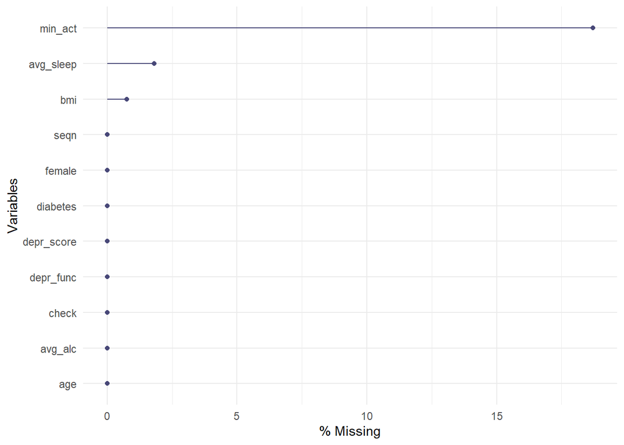

```r
gg_miss_var(nhanes_23, show_pct = TRUE)
```

# 5 Analysis 1

## 5.1 Managing Data for Analysis 1

To begin my first analysis, I will be using `depr_score` as my outcome and `avg_alc`, `age`, `female`, `avg_sleep`, `min_act`, and `diabetes` as my predictors. Using my imputed data set, I select the variables of interest, along with the identifier variable, and and create a training sample and a test sample.

```r
nh1 <- nhanes_imp |>
  select(seqn, avg_alc, age, female, avg_sleep, min_act, diabetes, depr_score)

set.seed(4323)

nh1_split <- initial_split(nh1, prop = 0.75)
nh1_train <- training(nh1_split)
nh1_test <- testing(nh1_split)

c(dim(nh1_train), dim(nh1_test))
```

```
[1] 1500    8  500    8
```

My final training set has 1500 observations on 8 variables, and the final test set has 500 observations on 8 variables.

## 5.2 Outcome and Predictor Details

Now, I want to explore what our data looks like in our singly imputed training sample for the predictors and outcome.

**The Outcome**

We first ensure that our outcome, `depr_score` is a count variable by checking that all of the values are non-negative integers.

```r
table(nh1_train$depr_score)
```

```
  1   2   3   4   5   6   7   8   9  10  11  12  13  14  15  16  17  18  19  20
273 247 190 140 120  90  82  58  45  49  44  33  31  15  16  10  12  10  10  10
 21  22  23  24  25
  5   3   3   3   1
```

Everything looks good, so I will create a histogram to better visualize the data.

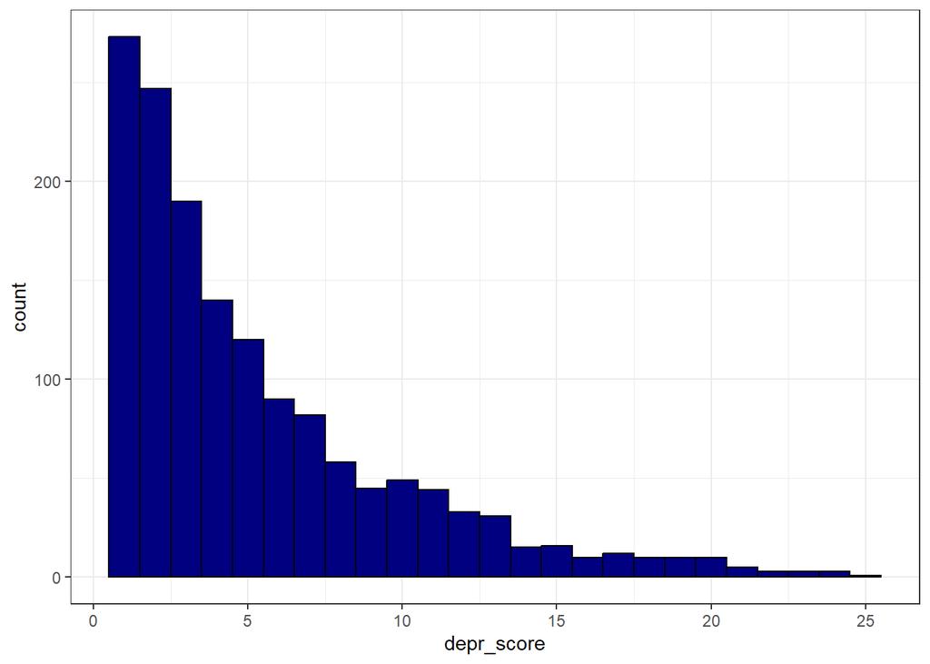

```r
ggplot(nh1_train, aes(x = depr_score)) +
  geom_histogram(bins = 25, fill = "navy", col = "black")
```

We see that we have a very right skewed distribution, which is common when looking at count variables. However, we have no zeros, as our outcome for analysis 2 is dependent on having a `depr_score` greater than zero, and we filtered to complete cases of that variable previously. As such, we will not consider any zero-inflated or hurdle models when we begin the analysis.

**The Predictors**

For our quantitative variables, we create some numerical summaries.

```r
df_stats(~avg_alc + age + avg_sleep + min_act, data = nh1_train) |>
  gt() |> fmt_number(mean:sd, decimals = 2)
```

| response | min | Q1 | median | Q3 | max | mean | sd | n | missing |
| --- | --- | --- | --- | --- | --- | --- | --- | --- | --- |
| avg_alc | 1 | 1 | 2.0 | 3.0 | 14 | 2.63 | 2.09 | 1500 | 0 |
| age | 21 | 35 | 51.0 | 64.0 | 79 | 49.83 | 16.43 | 1500 | 0 |
| avg_sleep | 3 | 7 | 7.5 | 8.5 | 13 | 7.64 | 1.39 | 1500 | 0 |
| min_act | 1 | 30 | 45.0 | 60.0 | 720 | 61.27 | 51.66 | 1500 | 0 |

This once again confirms that we have no missing values due to imputation and that our training sample contains 1500 observations. Otherwise, all of our values look appropriate.

For the categorical variables, we create some tabyls to look at the counts of each category.

```r
nh1_train |> tabyl(female) |>
  adorn_pct_formatting() |> gt()
```

| female | n | percent |
| --- | --- | --- |
| No | 630 | 42.0% |
| Yes | 870 | 58.0% |

```r
nh1_train |> tabyl(diabetes) |>
  adorn_pct_formatting() |> gt()
```

| diabetes | n | percent |
| --- | --- | --- |
| Yes | 170 | 11.3% |
| No | 1269 | 84.6% |
| Borderline | 61 | 4.1% |

Everything looks good here as well.

**describe**

We also run the `describe` function on the imputed training set so we can summarize the data we are using only for analysis 1.

```r
describe(nh1_train) |> html()
```

nh1_train  
8 Variables 1500 Observations

seqn

| n | missing | distinct |
| --- | --- | --- |
| 1500 | 0 | 1500 |

lowest : 130380 130386 130392 130397 130399 , highest: 142269 142279 142280 142283 142284

avg_alc

| n | missing | distinct | Info | Mean | pMedian | Gmd | .05 | .10 | .25 | .50 | .75 | .90 | .95 |
| --- | --- | --- | --- | --- | --- | --- | --- | --- | --- | --- | --- | --- | --- |
| 1500 | 0 | 13 | 0.929 | 2.625 | 2 | 1.924 | 1 | 1 | 1 | 2 | 3 | 5 | 6 |

```
 Value          1     2     3     4     5     6     7     8     9    10    11    12
 Frequency    473   492   237   105    77    48     6    16     6    13     3    23
 Proportion 0.315 0.328 0.158 0.070 0.051 0.032 0.004 0.011 0.004 0.009 0.002 0.015

 Value         14
 Frequency      1
 Proportion 0.001
```

age

| n | missing | distinct | Info | Mean | pMedian | Gmd | .05 | .10 | .25 | .50 | .75 | .90 | .95 |
| --- | --- | --- | --- | --- | --- | --- | --- | --- | --- | --- | --- | --- | --- |
| 1500 | 0 | 59 | 1 | 49.83 | 50 | 18.92 | 23 | 27 | 35 | 51 | 64 | 71 | 74 |

lowest : 21 22 23 24 25 , highest: 75 76 77 78 79

female

| n | missing | distinct |
| --- | --- | --- |
| 1500 | 0 | 2 |

```
 Value        No  Yes
 Frequency   630  870
 Proportion 0.42 0.58
```

avg_sleep

| n | missing | distinct | Info | Mean | pMedian | Gmd | .05 | .10 | .25 | .50 | .75 | .90 | .95 |
| --- | --- | --- | --- | --- | --- | --- | --- | --- | --- | --- | --- | --- | --- |
| 1500 | 0 | 21 | 0.983 | 7.638 | 7.75 | 1.524 | 5.0 | 6.0 | 7.0 | 7.5 | 8.5 | 9.0 | 10.0 |

lowest : 3 3.5 4 4.5 5 , highest: 11 11.5 12 12.5 13

min_act

| n | missing | distinct | Info | Mean | pMedian | Gmd | .05 | .10 | .25 | .50 | .75 | .90 | .95 |
| --- | --- | --- | --- | --- | --- | --- | --- | --- | --- | --- | --- | --- | --- |
| 1500 | 0 | 32 | 0.961 | 61.27 | 52.5 | 46.15 | 15 | 20 | 30 | 45 | 60 | 120 | 150 |

lowest : 1 2 3 4 5 , highest: 180 240 300 360 720

diabetes

| n | missing | distinct |
| --- | --- | --- |
| 1500 | 0 | 3 |

```
 Value             Yes         No Borderline
 Frequency         170       1269         61
 Proportion      0.113      0.846      0.041
```

depr_score

| n | missing | distinct | Info | Mean | pMedian | Gmd | .05 | .10 | .25 | .50 | .75 | .90 | .95 |
| --- | --- | --- | --- | --- | --- | --- | --- | --- | --- | --- | --- | --- | --- |
| 1500 | 0 | 25 | 0.986 | 5.316 | 4.5 | 4.738 | 1 | 1 | 2 | 4 | 7 | 12 | 15 |

lowest : 1 2 3 4 5 , highest: 21 22 23 24 25

## 5.3 Analysis 1 Modeling

For my analysis, I will be comparing a poisson model to a negative binomial model to see which performs best at prediction. We have no zeros in our outcome, so there is no use in trying zero-inflated or hurdle models.

### 5.3.1 Poisson Model

```r
pois_1 <- glm(depr_score ~ avg_alc + age + avg_sleep + min_act + female + diabetes,
              data = nh1_train, family = "poisson")

pois_1
```

```
Call:  glm(formula = depr_score ~ avg_alc + age + avg_sleep + min_act +
    female + diabetes, family = "poisson", data = nh1_train)

Coefficients:
       (Intercept)             avg_alc                 age           avg_sleep
          2.165381            0.050175           -0.009339           -0.024198
           min_act           femaleYes          diabetesNo  diabetesBorderline
          0.001039            0.199506           -0.209733           -0.072075

Degrees of Freedom: 1499 Total (i.e. Null);  1492 Residual
Null Deviance:      5176
Residual Deviance: 4773     AIC: 9607
```

We see no warnings, so our model should have fit properly.

**Parameters**

```r
model_parameters(pois_1, exponentiate = TRUE, ci = 0.90) |>
  gt() |> fmt_number(-df_error, decimals = 3)
```

| Parameter | Coefficient | SE | CI | CI_low | CI_high | z | df_error | p |
| --- | --- | --- | --- | --- | --- | --- | --- | --- |
| (Intercept) | 8.718 | 0.742 | 0.900 | 7.578 | 10.027 | 25.435 | Inf | 0.000 |
| avg_alc | 1.051 | 0.005 | 0.900 | 1.043 | 1.060 | 10.422 | Inf | 0.000 |
| age | 0.991 | 0.001 | 0.900 | 0.990 | 0.992 | −12.989 | Inf | 0.000 |
| avg_sleep | 0.976 | 0.008 | 0.900 | 0.963 | 0.989 | −3.016 | Inf | 0.003 |
| min_act | 1.001 | 0.000 | 0.900 | 1.001 | 1.001 | 5.194 | Inf | 0.000 |
| femaleYes | 1.221 | 0.029 | 0.900 | 1.174 | 1.269 | 8.475 | Inf | 0.000 |
| diabetesNo | 0.811 | 0.029 | 0.900 | 0.765 | 0.860 | −5.837 | Inf | 0.000 |
| diabetesBorderline | 0.930 | 0.059 | 0.900 | 0.838 | 1.032 | −1.141 | Inf | 0.254 |

Most of our coefficients show only a small effect here, but it appears the strongest relationship is between the `depr_score` and `female`, where being female is associated with having a higher `depr_score` than being male. There is also a strong relationship between the `depr_score` and `diabetes` when changing from ‘Yes’ to ‘No’, where not having diabetes is associated with having a lower `depr_score` than having diabetes.

**Performance**

```r
model_performance(pois_1) |>
  gt() |> fmt_number(decimals = 3)
```

| AIC | AICc | BIC | R2_Nagelkerke | RMSE | Sigma | Score_log | Score_spherical |
| --- | --- | --- | --- | --- | --- | --- | --- |
| 9,607.396 | 9,607.493 | 9,649.902 | 0.243 | 4.424 | 1.000 | −3.197 | 0.021 |

```r
glance(pois_1) |> gt()
```

| null.deviance | df.null | logLik | AIC | BIC | deviance | df.residual | nobs |
| --- | --- | --- | --- | --- | --- | --- | --- |
| 5175.942 | 1499 | -4795.698 | 9607.396 | 9649.902 | 4772.871 | 1492 | 1500 |

The Nagelkerke R<sup>2</sup> is a little low here, but these statistics will be more useful for comparing models later.

**Rootogram**

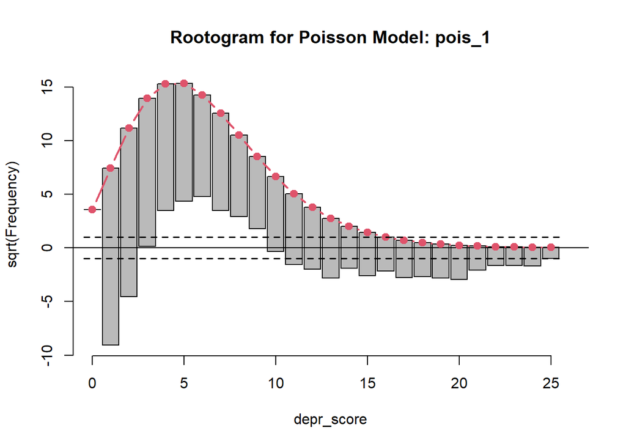

```r
plot(rootogram(pois_1, plot = FALSE), xlim = c(0, 26),
               main = "Rootogram for Poisson Model: pois_1")
```

Our rootogram does not look great here. The model severely under-predicts 1’s and 2’s, and over predicts 0’s, and 4 through 9. All greater `depr_score` values are under-predicted as well.

**check_model**

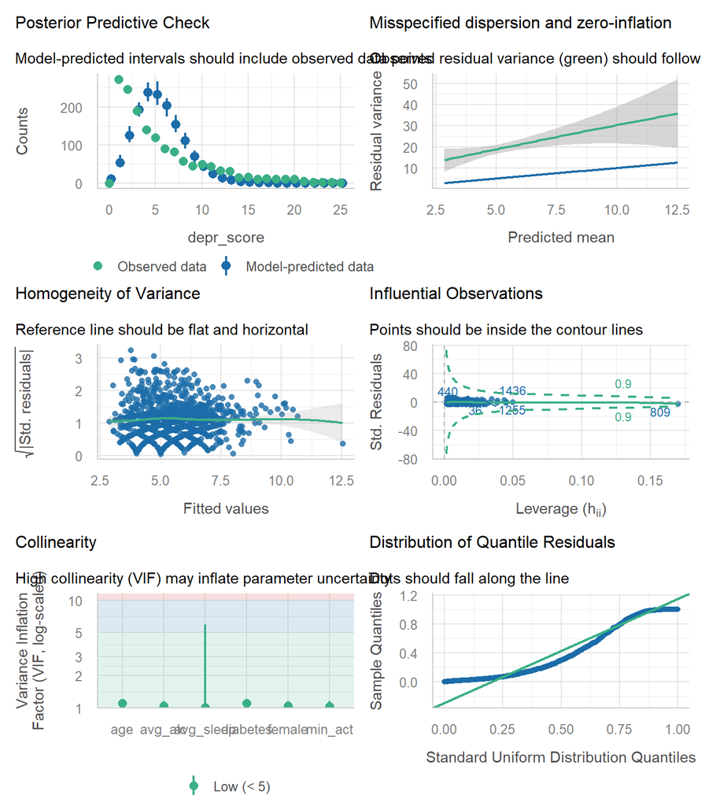

```r
check_model(pois_1)
```

Our `check_model` results are pretty poor. The posterior predictive check is pretty awful with many of the observed data points not being included in the model predicted intervals. The over-dispersion plot is also not that great, with the predicted line being lower than the observed line. The distribution plot is not great, with an ‘S’ shape that indicates the data is light-tailed. The other three plots look fine, meaning we have a consistent variance, no influential observations, and no issues with collinearity.

**Training Predictions**

```r
pois_1_aug <- augment(pois_1, nh1_train,
                       type.predict = "response")

mets <- metric_set(rsq, rmse, mae)

pois_1_summary <-
  mets(pois_1_aug, truth = depr_score, estimate = .fitted) |>
  mutate(model = "pois_1") |> relocate(model)


pois_1_summary |>
  gt() |> fmt_number(decimals = 3)
```

| model | .metric | .estimator | .estimate |
| --- | --- | --- | --- |
| pois_1 | rsq | standard | 0.073 |
| pois_1 | rmse | standard | 4.424 |
| pois_1 | mae | standard | 3.348 |

Our calculated training R<sup>2</sup> is even lower than the Nagelkerke R<sup>2</sup> given by the `model_performance` function. These statistics will be more useful for comparing models later.

### 5.3.2 Negative Binomial Model

```r
nb_1 <- glm.nb(depr_score ~ avg_alc + age + avg_sleep + min_act + female + diabetes,
              data = nh1_train)

nb_1
```

```
Call:  glm.nb(formula = depr_score ~ avg_alc + age + avg_sleep + min_act +
    female + diabetes, data = nh1_train, init.theta = 2.374739008,
    link = log)

Coefficients:
       (Intercept)             avg_alc                 age           avg_sleep
         2.1421220           0.0503643          -0.0090955          -0.0200336
           min_act           femaleYes          diabetesNo  diabetesBorderline
         0.0009456           0.1983502          -0.2257269          -0.0921737

Degrees of Freedom: 1499 Total (i.e. Null);  1492 Residual
Null Deviance:      1618
Residual Deviance: 1498     AIC: 7936
```

We see no warnings, so our model should have fit properly.

**Parameters**

```r
model_parameters(nb_1, exponentiate = TRUE, ci = 0.90) |>
  gt() |> fmt_number(-df_error, decimals = 3)
```

| Parameter | Coefficient | SE | CI | CI_low | CI_high | z | df_error | p |
| --- | --- | --- | --- | --- | --- | --- | --- | --- |
| (Intercept) | 8.517 | 1.320 | 0.900 | 6.662 | 10.894 | 13.818 | Inf | 0.000 |
| avg_alc | 1.052 | 0.010 | 0.900 | 1.035 | 1.069 | 5.254 | Inf | 0.000 |
| age | 0.991 | 0.001 | 0.900 | 0.989 | 0.993 | −7.040 | Inf | 0.000 |
| avg_sleep | 0.980 | 0.014 | 0.900 | 0.959 | 1.002 | −1.373 | Inf | 0.170 |
| min_act | 1.001 | 0.000 | 0.900 | 1.000 | 1.002 | 2.426 | Inf | 0.015 |
| femaleYes | 1.219 | 0.051 | 0.900 | 1.138 | 1.307 | 4.698 | Inf | 0.000 |
| diabetesNo | 0.798 | 0.052 | 0.900 | 0.715 | 0.889 | −3.442 | Inf | 0.001 |
| diabetesBorderline | 0.912 | 0.106 | 0.900 | 0.754 | 1.106 | −0.793 | Inf | 0.428 |

All of our coefficients are pretty similar to the poisson model. Once again we see the greatest differences in the `female` variable, where a change from ‘No’ to ‘Yes’ is associated with an increased `depr_score`, and in the `diabetes` variable, where a change from ‘Yes’ to ‘No’ is associated with a decreased `depr_score`.

**Performance**

```r
model_performance(nb_1) |>
  gt() |> fmt_number(decimals = 3)
```

| AIC | AICc | BIC | R2_Nagelkerke | RMSE | Sigma | Score_log | Score_spherical |
| --- | --- | --- | --- | --- | --- | --- | --- |
| 7,936.268 | 7,936.389 | 7,984.087 | 0.116 | 4.426 | 1.000 | −2.652 | 0.023 |

```r
glance(nb_1) |> gt()
```

| null.deviance | df.null | logLik | AIC | BIC | deviance | df.residual | nobs |
| --- | --- | --- | --- | --- | --- | --- | --- |
| 1617.602 | 1499 | -3959.134 | 7936.268 | 7984.087 | 1497.636 | 1492 | 1500 |

The Nagelkerke R<sup>2</sup> is even lower here compared to the poisson model.

**Rootogram**

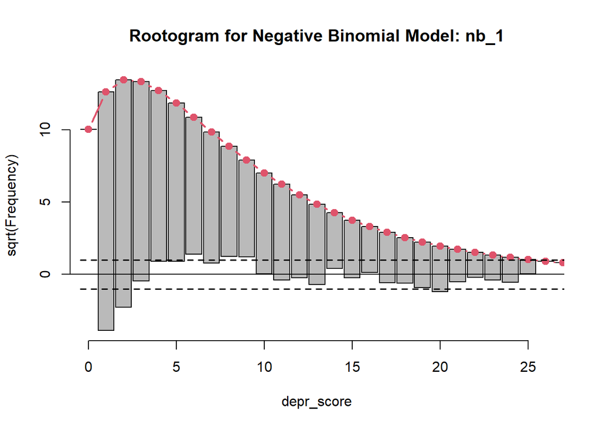

```r
plot(rootogram(nb_1, plot = FALSE), xlim = c(0, 26),
               main = "Rootogram for Negative Binomial Model: nb_1")
```

The rootogram here looks better than the poisson model, however 0s are over-predicted even more than the poisson model. Otherwise, 1s and 2s are once again under-predicted, and 4 through 9 are over-predicted. The larger numbers look to be predicted a little better than the poisson model, with most of them falling within the confidence interval.

**check_model**

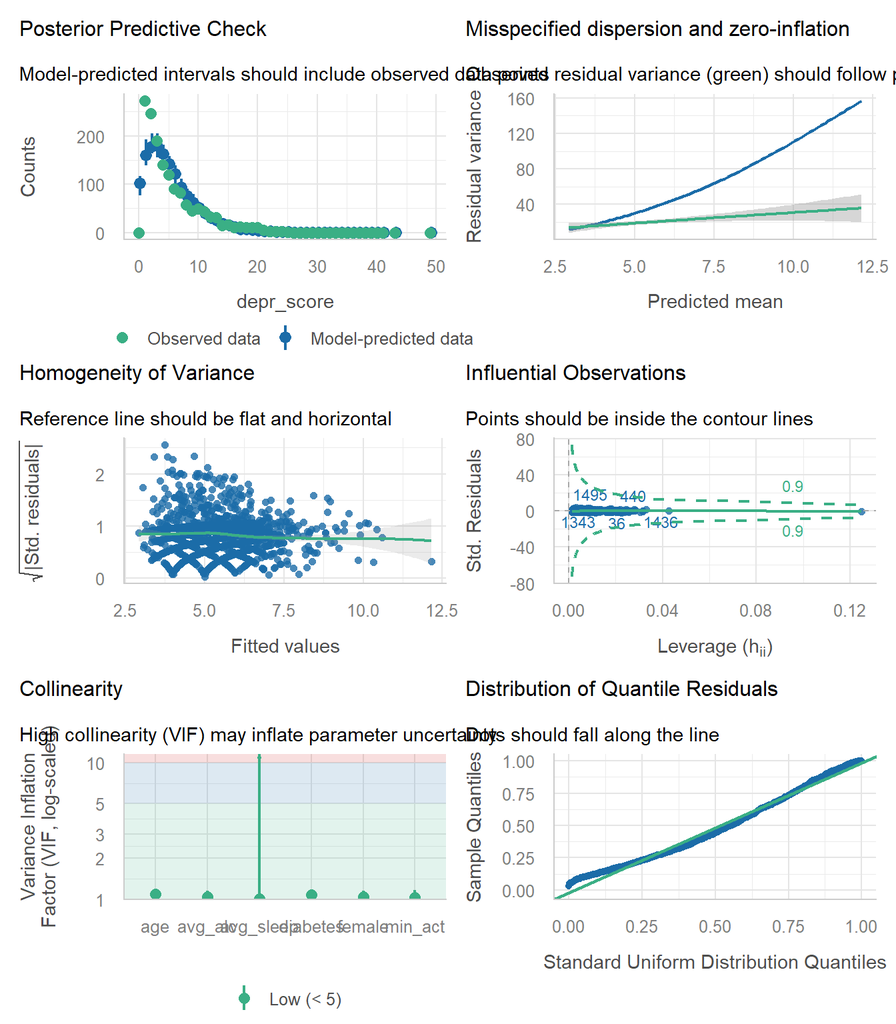

```r
check_model(nb_1)
```

The `check_model` results look better than the poisson model, but not great. The posterior predictive check is still very poor for smaller `depr_score` values, but it seems to perform better than the poisson model after that. The over-dispersion graph looks worse than the poisson model, with the lines diverging even more. All other graphs look fine, telling us we do not have any issues with constant variance, influential observations, collinearity, or distribution.

**Training Predictions**

```r
nb_1_aug <- augment(nb_1, nh1_train,
                       type.predict = "response")
nb_1_summary <-
  mets(nb_1_aug, truth = depr_score, estimate = .fitted) |>
  mutate(model = "nb_1") |> relocate(model)

nb_1_summary |>
  gt() |> fmt_number(decimals = 3)
```

| model | .metric | .estimator | .estimate |
| --- | --- | --- | --- |
| nb_1 | rsq | standard | 0.072 |
| nb_1 | rmse | standard | 4.426 |
| nb_1 | mae | standard | 3.349 |

All our statistics here as very similar to the poisson model, so I would not describe one as better than the other from this alone.

### 5.3.3 Comparing Models

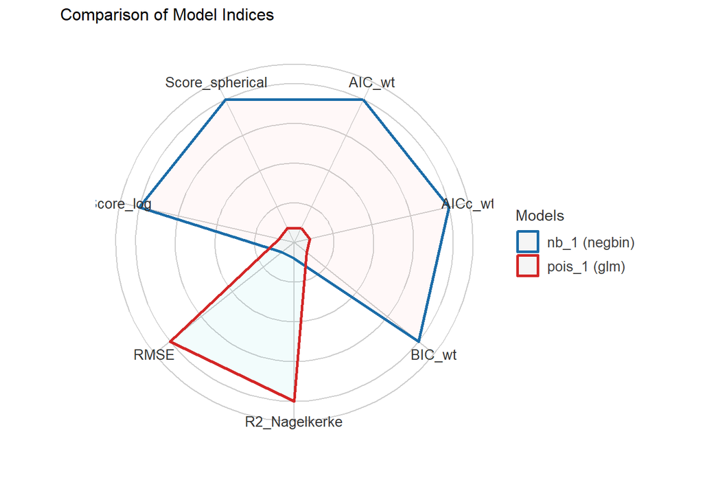

```r
plot(compare_performance(pois_1, nb_1))
```

```r
compare_performance(pois_1, nb_1)
```

```
# Comparison of Model Performance Indices

Name   |  Model |  AIC (weights) | AICc (weights) |  BIC (weights)
------------------------------------------------------------------
pois_1 |    glm | 9607.4 (<.001) | 9607.5 (<.001) | 9649.9 (<.001)
nb_1   | negbin | 7936.3 (>.999) | 7936.4 (>.999) | 7984.1 (>.999)

Name   | Nagelkerke's R2 |  RMSE | Sigma | Score_log | Score_spherical
----------------------------------------------------------------------
pois_1 |           0.243 | 4.424 |     1 |    -3.197 |           0.021
nb_1   |           0.116 | 4.426 |     1 |    -2.652 |           0.023
```

The `nb_1` model performs better than the `pois_1` model for AIC, AICc, and BIC, while the `pois_1` model performs better for Nagelkerke R<sup>2</sup> and just barely better for RMSE. However, this is still on the training data, so seeing how the models perform when predicting the test data will help us make a better decision.

### 5.3.4 Test Sample Predictions

```r
test_pois <- predict(pois_1, newdata = nh1_test, type = "response")
test_nb <- predict(nb_1, newdata = nh1_test, type = "response")

test_res <- bind_cols(nh1_test, poisson = test_pois, negbin = test_nb)

summ_pois <- mets(test_res, truth = depr_score, estimate = poisson) |>
  mutate(model = "Poisson")
summ_nb <- mets(test_res, truth = depr_score, estimate = negbin) |>
  mutate(model = "Neg. Binom.")

test_summ <- bind_rows(summ_pois, summ_nb) |>
  pivot_wider(names_from = model, values_from = .estimate)

test_summ |>
  select(-.estimator) |>
  gt() |> fmt_number(decimals = 4)
```

| .metric | Poisson | Neg. Binom. |
| --- | --- | --- |
| rsq | 0.0827 | 0.0825 |
| rmse | 4.5439 | 4.5448 |
| mae | 3.4121 | 3.4125 |

## 5.4 Final Model

In the end, I chose the negative binomial model to be our final model. This is primarily based on the rootogram looking better than the poisson model and better performance in the `check_model` graphs. The predictions in the test set were so close that I do not mind choosing `nb_1` even though it technically performed worse than `pois_1`.

### 5.4.1 Multiple Imputation

We will now perform multiple imputation to get our final model coefficients.

```r
nh1_mi <- nhanes_23 |>
  select(seqn, avg_alc, age, female, avg_sleep, min_act, diabetes, depr_score)

pct_miss_case(nh1_mi)
```

```
[1] 19.9
```

We are right on the edge of missing 20% of the data, so we will fit 25 imputations to cover our bases.

```r
nh1_25imps <- mice(nh1_mi, m = 25, seed = 4324,
                    print = FALSE)
```

```r
nb_mi <-
  with(nh1_25imps,
       glm.nb(depr_score ~ avg_alc + age + avg_sleep + min_act + female + diabetes))

nb_pool <- pool(nb_mi)
```

### 5.4.2 Final Model Parameters

```r
model_parameters(nb_pool, exponentiate = TRUE, ci = 0.90) |>
  gt() |> fmt_number(-df_error, decimals = 3)
```

| Parameter | Coefficient | SE | CI | CI_low | CI_high | z | df_error | p |
| --- | --- | --- | --- | --- | --- | --- | --- | --- |
| (Intercept) | 10.328 | 1.409 | 0.900 | 8.251 | 12.927 | 17.116 | 1744.947 | 0.000 |
| avg_alc | 1.054 | 0.009 | 0.900 | 1.040 | 1.069 | 6.279 | 1971.498 | 0.000 |
| age | 0.990 | 0.001 | 0.900 | 0.988 | 0.992 | −8.731 | 1987.385 | 0.000 |
| avg_sleep | 0.969 | 0.012 | 0.900 | 0.949 | 0.990 | −2.477 | 1627.489 | 0.013 |
| min_act | 1.001 | 0.000 | 0.900 | 1.000 | 1.001 | 1.372 | 148.361 | 0.172 |
| femaleYes | 1.183 | 0.044 | 0.900 | 1.113 | 1.257 | 4.558 | 1932.613 | 0.000 |
| diabetesNo | 0.759 | 0.042 | 0.900 | 0.693 | 0.832 | −4.952 | 1983.967 | 0.000 |
| diabetesBorderline | 0.938 | 0.095 | 0.900 | 0.794 | 1.108 | −0.632 | 1986.009 | 0.527 |

Other than the intercept term, most of our coefficients after multiple imputation are fairly close to what they were after single imputation, but some are a little more off. I believe this is due to how much data was missing in this case, as we missing data in approximately 20% of cases, allowing for more variability after multiple imputation.

Looking at the `female` variable, if we have two subjects that have the same `avg_alc`, `age`, `avg_sleep`, `min_act`, and `diabetes` values, but subject A is male while subject B is female, the model predicts that subject B will have a `depr_score` that is approximately 18% larger than subject A. In addition, our data are consistent at the 90% confidence level with an incidence rate ratio comparing A to B falling between 1.113 and 1.257, assuming both that our data are a random sample of the population of interest, and that our model is correct.

# 6 Analysis 2

## 6.1 Managing Data for Analysis 2

To begin my second analysis, I will be using `depr_func` as my outcome and `age`, `female`, `bmi`, and `depr_score` as my predictors. Using my imputed data set, I select the variables of interest, along with the identifier variable, and and create a training sample and a test sample.

```r
nh2 <- nhanes_imp |>
  select(seqn, age, female, bmi, depr_score, depr_func)

set.seed(4325)

nh2_split <- initial_split(nh2, prop = 0.75)
nh2_train <- training(nh2_split)
nh2_test <- testing(nh2_split)

c(dim(nh2_train), dim(nh2_test))
```

```
[1] 1500    6  500    6
```

My final training set has 1500 observations on 6 variables, and the final test set has 500 observations on 6 variables.

## 6.2 Outcome and Predictor Details

**Outcome**

`depr_func` is an ordinal categorical outcome, so first we ensure that it is coded as an ordered factor.

```r
is.ordered(nh2_train$depr_func)
```

```
[1] TRUE
```

With that confirmed, we can create a table and bar graph to describe our outcome in our training set.

```r
nh2_train |> tabyl(depr_func) |>
  adorn_pct_formatting() |> gt()
```

| depr_func | n | percent |
| --- | --- | --- |
| Not at all | 937 | 62.5% |
| Several days | 471 | 31.4% |
| Over half the days | 66 | 4.4% |
| Nearly every day | 26 | 1.7% |

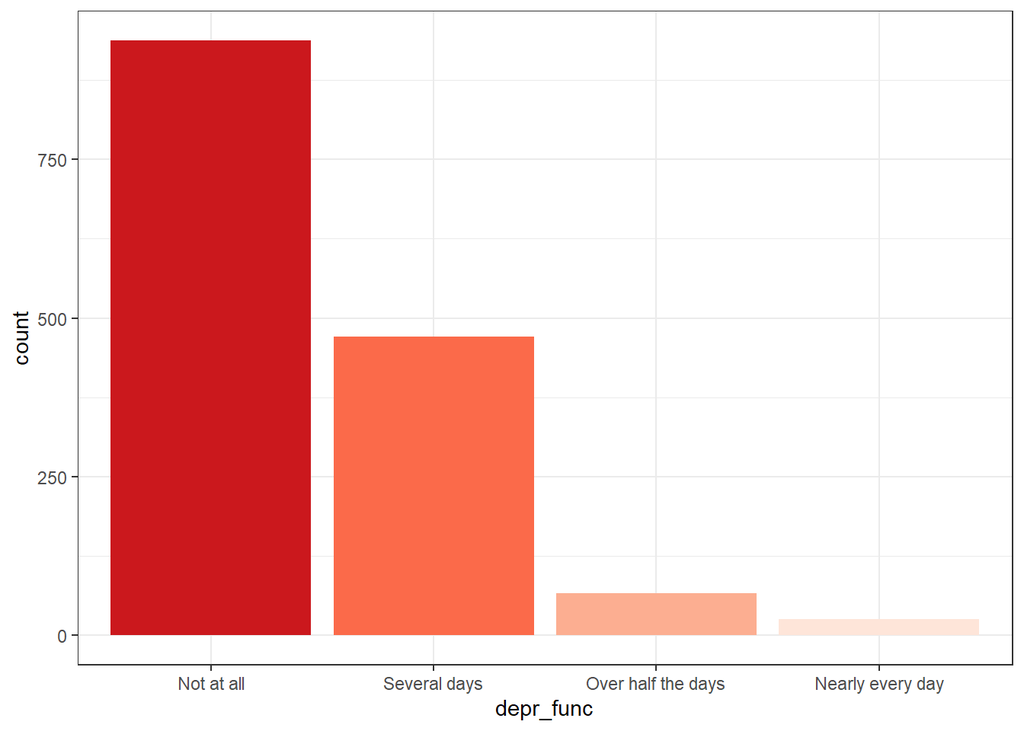

```r
ggplot(nh2_train, aes(x = depr_func, fill = depr_func)) +
  geom_bar() +
  scale_fill_brewer(type = "seq", palette = "Reds", direction = '-1') +
  guides(fill = "none")
```

Our categories are rather unbalanced, but we have over 20 observations in each category, so we will continue.

**Predictors**

For our quantitative variables, we create some numerical summaries.

```r
df_stats(~age + bmi + depr_score, data = nh2_train) |>
  gt() |> fmt_number(mean:sd, decimals = 2)
```

| response | min | Q1 | median | Q3 | max | mean | sd | n | missing |
| --- | --- | --- | --- | --- | --- | --- | --- | --- | --- |
| age | 21.0 | 35 | 51.0 | 64 | 79.0 | 49.64 | 16.41 | 1500 | 0 |
| bmi | 14.9 | 25 | 28.8 | 34 | 64.7 | 30.32 | 7.56 | 1500 | 0 |
| depr_score | 1.0 | 2 | 4.0 | 7 | 25.0 | 5.37 | 4.71 | 1500 | 0 |

This once again confirms that we have no missing values due to imputation and that our training sample contains 1500 observations. Otherwise, all of our values look appropriate.

For the binary variable, we create a tabyl to look at the counts of each category.

```r
nh2_train |> tabyl(female) |>
  adorn_pct_formatting() |> gt()
```

| female | n | percent |
| --- | --- | --- |
| No | 615 | 41.0% |
| Yes | 885 | 59.0% |

Everything looks fine here too.

**describe**

We also run the `describe` function on the imputed training set so we can summarize the data we are using only for analysis 2.

```r
describe(nh2_train) |> html()
```

nh2_train  
6 Variables 1500 Observations

seqn

| n | missing | distinct |
| --- | --- | --- |
| 1500 | 0 | 1500 |

lowest : 130380 130397 130406 130413 130416 , highest: 142269 142279 142280 142286 142300

age

| n | missing | distinct | Info | Mean | pMedian | Gmd | .05 | .10 | .25 | .50 | .75 | .90 | .95 |
| --- | --- | --- | --- | --- | --- | --- | --- | --- | --- | --- | --- | --- | --- |
| 1500 | 0 | 59 | 1 | 49.64 | 49.5 | 18.9 | 24 | 26 | 35 | 51 | 64 | 70 | 74 |

lowest : 21 22 23 24 25 , highest: 75 76 77 78 79

female

| n | missing | distinct |
| --- | --- | --- |
| 1500 | 0 | 2 |

```
 Value        No  Yes
 Frequency   615  885
 Proportion 0.41 0.59
```

bmi

| n | missing | distinct | Info | Mean | pMedian | Gmd | .05 | .10 | .25 | .50 | .75 | .90 | .95 |
| --- | --- | --- | --- | --- | --- | --- | --- | --- | --- | --- | --- | --- | --- |
| 1500 | 0 | 322 | 1 | 30.32 | 29.55 | 8.182 | 20.8 | 22.2 | 25.0 | 28.8 | 34.0 | 40.5 | 45.0 |

lowest : 14.9 16.7 16.8 17.1 17.3 , highest: 59.1 60.6 61.4 63 64.7

depr_score

| n | missing | distinct | Info | Mean | pMedian | Gmd | .05 | .10 | .25 | .50 | .75 | .90 | .95 |
| --- | --- | --- | --- | --- | --- | --- | --- | --- | --- | --- | --- | --- | --- |
| 1500 | 0 | 25 | 0.986 | 5.365 | 4.5 | 4.825 | 1 | 1 | 2 | 4 | 7 | 12 | 16 |

lowest : 1 2 3 4 5 , highest: 21 22 23 24 25

depr_func

| n | missing | distinct |
| --- | --- | --- |
| 1500 | 0 | 4 |

```
 Value              Not at all       Several days Over half the days
 Frequency                 937                471                 66
 Proportion              0.625              0.314              0.044

 Value        Nearly every day
 Frequency                  26
 Proportion              0.017
```

## 6.3 Analysis 2 Modeling

Since we have an ordinal outcome, I have decided to compare a POLR model and a multinomial model.

### 6.3.1 POLR model

```r
polr_2 <- polr(depr_func ~ age + bmi + depr_score + female,
                data = nh2_train, Hess = TRUE)

polr_2
```

```
Call:
polr(formula = depr_func ~ age + bmi + depr_score + female, data = nh2_train,
    Hess = TRUE)

Coefficients:
        age         bmi  depr_score   femaleYes
-0.01734495 -0.01705913  0.37813281 -0.07974985

Intercepts:
            Not at all|Several days     Several days|Over half the days
                           1.112462                            4.927269
Over half the days|Nearly every day
                           6.819955

Residual Deviance: 1810.298
AIC: 1824.298
```

Our model fit 3 intercepts and 4 slopes, and there are no warnings present, so the model should have fit properly.

We will also fit the same model using `lrm` to use with certain functions later on.

```r
d1 <- datadist(nh2_train)
options(datadist = "d1")

lrm_2 <- lrm(depr_func ~ age + bmi + depr_score + female,
                data = nh2_train, x = TRUE, y = TRUE)

lrm_2
```

```
Logistic Regression Model

lrm(formula = depr_func ~ age + bmi + depr_score + female, data = nh2_train,
    x = TRUE, y = TRUE)


Frequencies of Responses

        Not at all       Several days Over half the days   Nearly every day
               937                471                 66                 26

                        Model Likelihood       Discrimination    Rank Discrim.
                              Ratio Test              Indexes          Indexes
Obs           1500    LR chi2     785.84       R2       0.496    C       0.871
max |deriv| 0.0002    d.f.             4      R2(4,1500)0.406    Dxy     0.741
                      Pr(> chi2) <0.0001    R2(4,1087.8)0.513    gamma   0.741
                                               Brier    0.138    tau-a   0.377

                      Coef    S.E.   Wald Z Pr(>|Z|)
y>=Several days       -1.1124 0.3118  -3.57 0.0004
y>=Over half the days -4.9274 0.3692 -13.34 <0.0001
y>=Nearly every day   -6.8201 0.4310 -15.82 <0.0001
age                   -0.0173 0.0038  -4.54 <0.0001
bmi                   -0.0171 0.0082  -2.07 0.0383
depr_score             0.3781 0.0173  21.83 <0.0001
female=Yes            -0.0798 0.1273  -0.63 0.5308
```

**Parameters**

```r
model_parameters(polr_2, exponentiate = TRUE, ci = 0.90) |>
  gt() |> fmt_number(-df_error, decimals = 3)
```

| Parameter | Coefficient | SE | CI | CI_low | CI_high | t | df_error | p | Component |
| --- | --- | --- | --- | --- | --- | --- | --- | --- | --- |
| Not at all\|Several days | 3.042 | 0.948 | 0.900 | 1.821 | 5.081 | 3.568 | 1493 | 0.000 | alpha |
| Several days\|Over half the days | 138.002 | 50.958 | 0.900 | 75.153 | 253.412 | 13.344 | 1493 | 0.000 | alpha |
| Over half the days\|Nearly every day | 915.944 | 394.811 | 0.900 | 450.569 | 1,861.984 | 15.822 | 1493 | 0.000 | alpha |
| age | 0.983 | 0.004 | 0.900 | 0.977 | 0.989 | −4.544 | 1493 | 0.000 | beta |
| bmi | 0.983 | 0.008 | 0.900 | 0.970 | 0.996 | −2.072 | 1493 | 0.038 | beta |
| depr_score | 1.460 | 0.025 | 0.900 | 1.419 | 1.503 | 21.826 | 1493 | 0.000 | beta |
| femaleYes | 0.923 | 0.117 | 0.900 | 0.749 | 1.139 | −0.627 | 1493 | 0.531 | beta |

As I expected, the `depr_score` seems to be having the largest effect here, with a 1 point increase in `depr_score` being associated with a 1.460 times greater odds of moving into a worse `depr_func` category.

**Performance**

```r
model_performance(polr_2) |>
  gt() |> fmt_number(decimals = 3)
```

```
Can't calculate log-loss.
```

```
Can't calculate proper scoring rules for ordinal, multinomial or
  cumulative link models.
```

| AIC | AICc | BIC | R2_Nagelkerke | RMSE | Sigma |
| --- | --- | --- | --- | --- | --- |
| 1,824.298 | 1,824.373 | 1,861.491 | 0.496 | 1.409 | 1.100 |

```r
glance(polr_2) |> gt()
```

| edf | logLik | AIC | BIC | deviance | df.residual | nobs |
| --- | --- | --- | --- | --- | --- | --- |
| 7 | -905.149 | 1824.298 | 1861.491 | 1810.298 | 1493 | 1500 |

I am quite happy with the Nagelkerke R<sup>2</sup> here, but it will be more important when comparing models later on.

**Classification**

```r
addmargins(table(predict(polr_2), nh2_train$depr_func,
                 dnn = c("predicted", "actual")))
```

```
                    actual
predicted            Not at all Several days Over half the days
  Not at all                855          209                  6
  Several days               80          241                 48
  Over half the days          1           16                  7
  Nearly every day            1            5                  5
  Sum                       937          471                 66
                    actual
predicted            Nearly every day  Sum
  Not at all                        1 1071
  Several days                     11  380
  Over half the days                8   32
  Nearly every day                  6   17
  Sum                              26 1500
```

A total of 1109 predictions were correct, giving us an accuracy of 73.9%. All our categories are predicted multiple times, so I am quite happy with this model so far.

**check_model**

```
Cannot simulate residuals for models of class `polr`. Please try
  `check_model(..., residual_type = "normal")` instead.
```

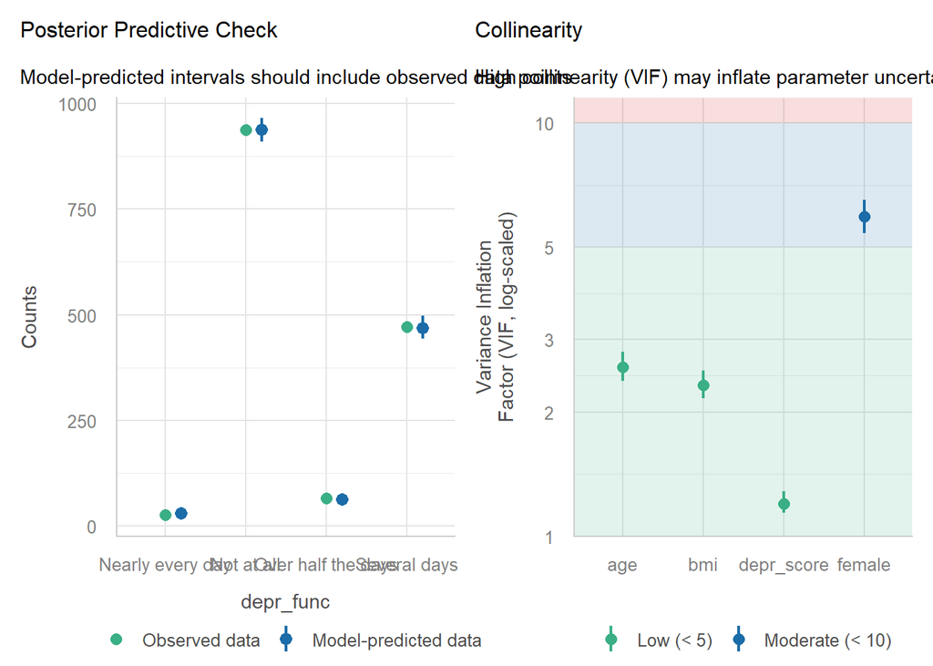

```r
check_model(polr_2)
```

**Validated Summaries**

```r
set.seed(4326)
validate(lrm_2, B = 300)
```

```
          index.orig training    test optimism index.corrected   Lower   Upper
Dxy           0.7411   0.7445  0.7393   0.0052          0.7359  0.7036  0.7695
R2            0.4956   0.5000  0.4941   0.0060          0.4896  0.4457  0.5333
Intercept     0.0000   0.0000 -0.0044   0.0044         -0.0044 -0.4287  0.4320
Slope         1.0000   1.0000  0.9870   0.0130          0.9870  0.8788  1.1017
Emax          0.0000   0.0000  0.0389  -0.0389          0.0389 -0.0115  0.1166
D             0.5232   0.5296  0.5211   0.0085          0.5148  0.4469  0.5786
U            -0.0013  -0.0013 -0.9160   0.9147         -0.9160 -0.9248 -0.9073
Q             0.5246   0.5309  1.4371  -0.9062          1.4308  1.3585  1.5010
B             0.0435   0.0431  0.0437  -0.0006          0.0441  0.0367  0.0518
g             1.9256   1.9490  1.9208   0.0283          1.8974  1.7095  2.0835
gp            0.3166   0.3180  0.1021   0.2159          0.1007  0.0838  0.1188
            n
Dxy       300
R2        300
Intercept 300
Slope     300
Emax      300
D         300
U         300
Q         300
B         300
g         300
gp        300
```

Our validated R<sup>2</sup> is 0.4896 and our validated C statistic is 0.868.

**ggplot(Predict)**

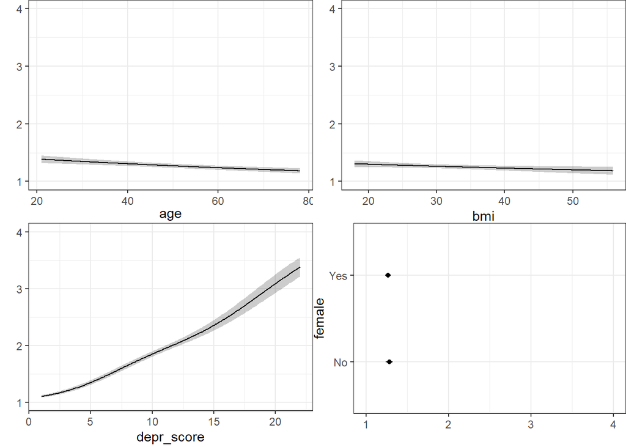

```r
ggplot(Predict(lrm_2, fun = Mean(lrm_2, code = TRUE)))
```

We see here that as `age`, `bmi`, and `female` all have little impact on which category of `depr_func` a subject falls into. `depr_score` however, has a much larger impact, with higher `depr_scores` being more likely to fall into higher `depr_func` categories.

**Predicting New Subjects**

Now, so I can look at predictions in new subjects, I am going to create 2 subjects with the following values:

| Name | `age` | `female` | `bmi` | `depr_score` |
| --- | --- | --- | --- | --- |
| Subject 1 | 25 | yes | 30 | 18 |
| Subject 2 | 65 | no | 20 | 6 |

```r
new1 <- tibble(
  name = c("Subject 1", "Subject 2"),
  age = c(25, 65),
  female = c('Yes', 'No'),
  bmi = c(30, 20),
  depr_score = c(18, 6)
)
```

```r
polr_preds <- predict(polr_2, newdata = new1, type = "p")

polr_preds_tab <- cbind(new1, polr_preds)

polr_preds_tab |>
  gt() |> fmt_number('Not at all':'Nearly every day', decimals = 3)
```

| name | age | female | bmi | depr_score | Not at all | Several days | Over half the days | Nearly every day |
| --- | --- | --- | --- | --- | --- | --- | --- | --- |
| Subject 1 | 25 | Yes | 30 | 18 | 0.009 | 0.289 | 0.440 | 0.261 |
| Subject 2 | 65 | No | 20 | 6 | 0.577 | 0.407 | 0.013 | 0.002 |

From this, we can see that our model would predict subject 1 is in the ‘Over half the days’ category, while subject B is in the ‘Not at all’ category.

### 6.3.2 Multinomial Model

```r
mult_2 <- multinom(depr_func ~ age + bmi + depr_score + female,
                data = nh2_train, trace = FALSE)

mult_2
```

```
Call:
multinom(formula = depr_func ~ age + bmi + depr_score + female,
    data = nh2_train, trace = FALSE)

Coefficients:
                   (Intercept)          age         bmi depr_score  femaleYes
Several days         -1.216547 -0.016471303 -0.02124579  0.4134190 -0.1508151
Over half the days   -4.338544 -0.035017056 -0.03315857  0.6118672  0.2110324
Nearly every day     -8.660148 -0.006991685 -0.02406793  0.7495868 -0.2119699

Residual Deviance: 1794.296
AIC: 1824.296
```

Our model fit 3 intercepts and 12 slopes, and there are no warnings present, so the model should have fit properly.

**Parameters**

```r
model_parameters(mult_2, exponentiate = TRUE, ci = 0.90) |>
  gt() |> fmt_number(-df_error, decimals = 3)
```

| Parameter | Coefficient | SE | CI | CI_low | CI_high | z | df_error | p | Response |
| --- | --- | --- | --- | --- | --- | --- | --- | --- | --- |
| (Intercept) | 0.296 | 0.104 | 0.900 | 0.166 | 0.528 | −3.462 | Inf | 0.001 | Several days |
| age | 0.984 | 0.004 | 0.900 | 0.977 | 0.991 | −3.826 | Inf | 0.000 | Several days |
| bmi | 0.979 | 0.009 | 0.900 | 0.964 | 0.994 | −2.279 | Inf | 0.023 | Several days |
| depr_score | 1.512 | 0.037 | 0.900 | 1.452 | 1.575 | 16.685 | Inf | 0.000 | Several days |
| femaleYes | 0.860 | 0.122 | 0.900 | 0.681 | 1.086 | −1.064 | Inf | 0.288 | Several days |
| (Intercept) | 0.013 | 0.010 | 0.900 | 0.004 | 0.045 | −5.773 | Inf | 0.000 | Over half the days |
| age | 0.966 | 0.009 | 0.900 | 0.950 | 0.981 | −3.655 | Inf | 0.000 | Over half the days |
| bmi | 0.967 | 0.018 | 0.900 | 0.937 | 0.998 | −1.736 | Inf | 0.083 | Over half the days |
| depr_score | 1.844 | 0.068 | 0.900 | 1.736 | 1.959 | 16.648 | Inf | 0.000 | Over half the days |
| femaleYes | 1.235 | 0.402 | 0.900 | 0.723 | 2.110 | 0.648 | Inf | 0.517 | Over half the days |
| (Intercept) | 0.000 | 0.000 | 0.900 | 0.000 | 0.002 | −6.363 | Inf | 0.000 | Nearly every day |
| age | 0.993 | 0.014 | 0.900 | 0.970 | 1.016 | −0.496 | Inf | 0.620 | Nearly every day |
| bmi | 0.976 | 0.028 | 0.900 | 0.931 | 1.024 | −0.831 | Inf | 0.406 | Nearly every day |
| depr_score | 2.116 | 0.114 | 0.900 | 1.937 | 2.311 | 13.969 | Inf | 0.000 | Nearly every day |
| femaleYes | 0.809 | 0.398 | 0.900 | 0.360 | 1.819 | −0.430 | Inf | 0.667 | Nearly every day |

Once again, `depr_score` seems to be having the largest effect here, in all categories, with a 1 point increase in `depr_score` being associated with a 2.116 times greater odds of moving into a from ‘Not at all’ to ‘Nearly every day’.

**Performance**

```r
model_performance(mult_2) |>
  gt() |> fmt_number(decimals = 3)
```

```
Can't calculate log-loss.
```

```
Can't calculate proper scoring rules for ordinal, multinomial or
  cumulative link models.
```

| AIC | AICc | BIC | R2 | R2_adjusted | RMSE | Sigma |
| --- | --- | --- | --- | --- | --- | --- |
| 1,824.296 | 1,824.620 | 1,903.995 | 0.309 | 0.308 | 0.295 | 1.099 |

```r
glance(mult_2) |> gt()
```

| edf | deviance | AIC | nobs |
| --- | --- | --- | --- |
| 15 | 1794.296 | 1824.296 | 1500 |

We are getting a lower R<sup>2</sup> here than the POLR model, but it is still okay.

**Classification**

```r
addmargins(table(predict(mult_2), nh2_train$depr_func,
                 dnn = c("predicted", "actual")))
```

```
                    actual
predicted            Not at all Several days Over half the days
  Not at all                855          202                  6
  Several days               81          261                 53
  Over half the days          1            4                  6
  Nearly every day            0            4                  1
  Sum                       937          471                 66
                    actual
predicted            Nearly every day  Sum
  Not at all                        1 1064
  Several days                     16  411
  Over half the days                4   15
  Nearly every day                  5   10
  Sum                              26 1500
```

**check_model**

```
Cannot simulate residuals for models of class `multinom`. Please try
  `check_model(..., residual_type = "normal")` instead.
```

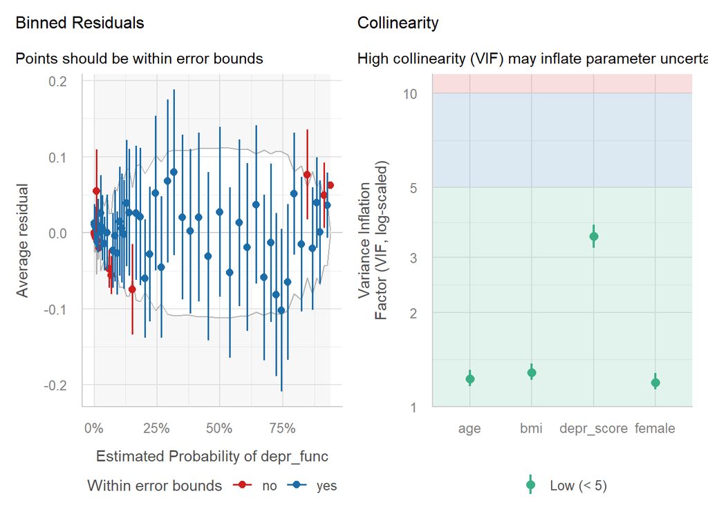

```r
check_model(mult_2)
```

**Predicting New Subjects**

```r
mult_preds <- predict(mult_2, newdata = new1, type = "p")

mult_preds_tab <- cbind(new1, mult_preds)

mult_preds_tab |>
  gt() |> fmt_number('Not at all':'Nearly every day', decimals = 3)
```

| name | age | female | bmi | depr_score | Not at all | Several days | Over half the days | Nearly every day |
| --- | --- | --- | --- | --- | --- | --- | --- | --- |
| Subject 1 | 25 | Yes | 30 | 18 | 0.003 | 0.441 | 0.437 | 0.120 |
| Subject 2 | 65 | No | 20 | 6 | 0.547 | 0.434 | 0.015 | 0.003 |

This time, subject 1 is predicted to be in the ‘Several days’ category, while subject 2 is predicted to be in the ‘Not at all’ category.

## 6.4 Comparing Models

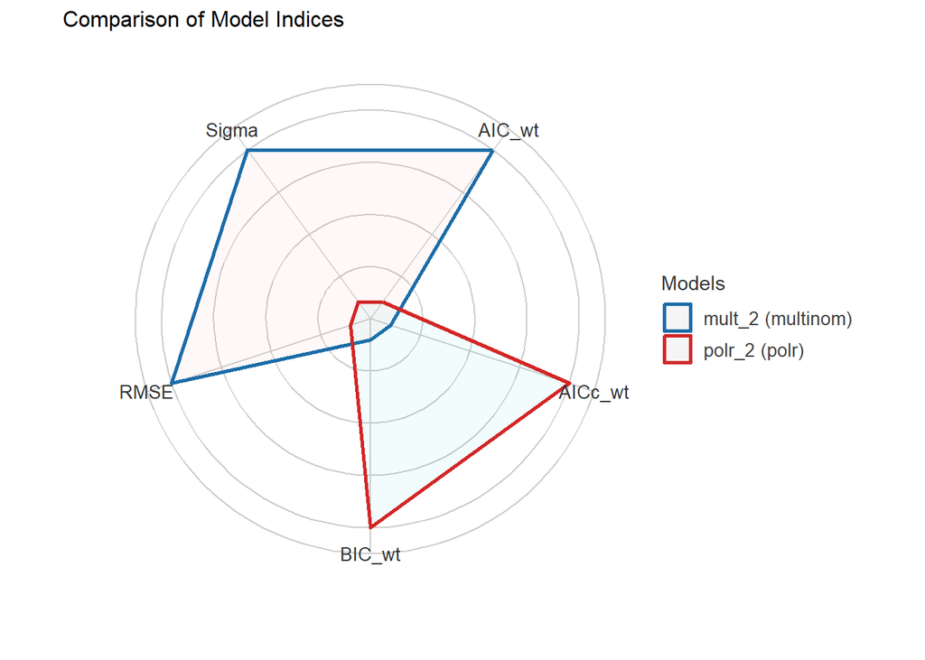

```r
plot(compare_performance(polr_2, mult_2))
```

From our graph, it appears no model completely dominates the other using these statistics alone.

### 6.4.1 Likelihood Ratio Test

```r
LL_polr <- logLik(polr_2) # polr_2 uses 7 df
LL_mult <- logLik(mult_2) # mult_2 uses 15 df

G = -2 * (LL_polr[1] - LL_mult[1])

pchisq(G, 15-7, lower.tail = FALSE)
```

```
[1] 0.04235701
```

Our likelihood ratio test suggests that the multinomial model fits better than our proportional odds model.

### 6.4.2 Test Sample Classification

```r
addmargins(table(predict(polr_2, newdata = nh2_test),
                 nh2_test$depr_func,
                 dnn = c("predicted", "actual")))
```

```
                    actual
predicted            Not at all Several days Over half the days
  Not at all                292           64                  0
  Several days               28           79                 22
  Over half the days          0            2                  4
  Nearly every day            0            3                  1
  Sum                       320          148                 27
                    actual
predicted            Nearly every day Sum
  Not at all                        0 356
  Several days                      3 132
  Over half the days                0   6
  Nearly every day                  2   6
  Sum                               5 500
```

For the POLR model, the accuracy in the test set is 75.4%.

```r
addmargins(table(predict(mult_2, newdata = nh2_test),
                 nh2_test$depr_func,
                 dnn = c("predicted", "actual")))
```

```
                    actual
predicted            Not at all Several days Over half the days
  Not at all                291           61                  0
  Several days               29           84                 26
  Over half the days          0            2                  1
  Nearly every day            0            1                  0
  Sum                       320          148                 27
                    actual
predicted            Nearly every day Sum
  Not at all                        0 352
  Several days                      3 142
  Over half the days                2   5
  Nearly every day                  0   1
  Sum                               5 500
```

For the multinomial model, the accuracy in the test set is 75.2%

## 6.5 Final Model

I will be choosing the POLR model for my final model, as it is simpler while performing very similarly to the multinomial model in the test and training sets. The p-value from our likelihood ratio test does favor the multinomial model, but in-sample and test sample performance does not show substantially better performance, so I feel comfortable choosing the POLR model.

### 6.5.1 Multiple Imputation

```r
nh2_mi <- nhanes_23 |>
  select(seqn, age, female, bmi, depr_score, depr_func)

pct_miss_case(nh2_mi)
```

```
[1] 0.75
```

```r
nh2_5imps <- mice(nh2_mi, m = 25, seed = 4327,
                  print = FALSE)
polr_mi <-
  with(nh2_5imps,
       polr(depr_func ~ age + bmi + depr_score + female,
            Hess = TRUE))

polr_pool <- pool(polr_mi)
```

### 6.5.2 Final Model Parameters

```r
model_parameters(polr_pool, exponentiate = TRUE, ci = 0.90) |>
  gt() |> fmt_number(decimals = 3)
```

| Parameter | Coefficient | SE | CI | CI_low | CI_high | t | df_error | p |
| --- | --- | --- | --- | --- | --- | --- | --- | --- |
| age | 0.984 | 0.003 | 0.900 | 0.978 | 0.989 | −5.017 | 1,990.890 | 0.000 |
| bmi | 0.986 | 0.007 | 0.900 | 0.975 | 0.998 | −1.973 | 1,929.714 | 0.049 |
| depr_score | 1.469 | 0.022 | 0.900 | 1.432 | 1.506 | 25.332 | 1,990.176 | 0.000 |
| femaleYes | 0.996 | 0.110 | 0.900 | 0.831 | 1.194 | −0.036 | 1,990.677 | 0.971 |
| Not at all\|Several days | 3.825 | 1.040 | 0.900 | 2.445 | 5.984 | 4.934 | 1,969.967 | 0.000 |
| Several days\|Over half the days | 162.254 | 52.078 | 0.900 | 95.677 | 275.160 | 15.856 | 1,979.180 | 0.000 |
| Over half the days\|Nearly every day | 1,277.028 | 488.441 | 0.900 | 680.528 | 2,396.377 | 18.700 | 1,983.903 | 0.000 |

Other than the intercept terms, all of our coefficients after multiple imputation are fairly close to what they were after single imputation, enough that I am not worried about it.

Looking at the `depr_score` variable, if we have two subjects that have the same `age`, `female`, and `bmi` values, but subject A has a `depr_score` 1 point higher than subject B, the model predicts subject A’s odds of rising into a larger `depr_func` category is 1.469 times the odds of subject B. In addition, our data are consistent at the 90% confidence level with an odds ratio comparing A to B falling between 1.432 and 1.506, assuming both that our data are a random sample of the population of interest, and that our model is correct.

### 6.5.3 Effect Size

As my research question is focused on effect size, I want to create a nomogram and effect size graph to get a better look at what is going on.

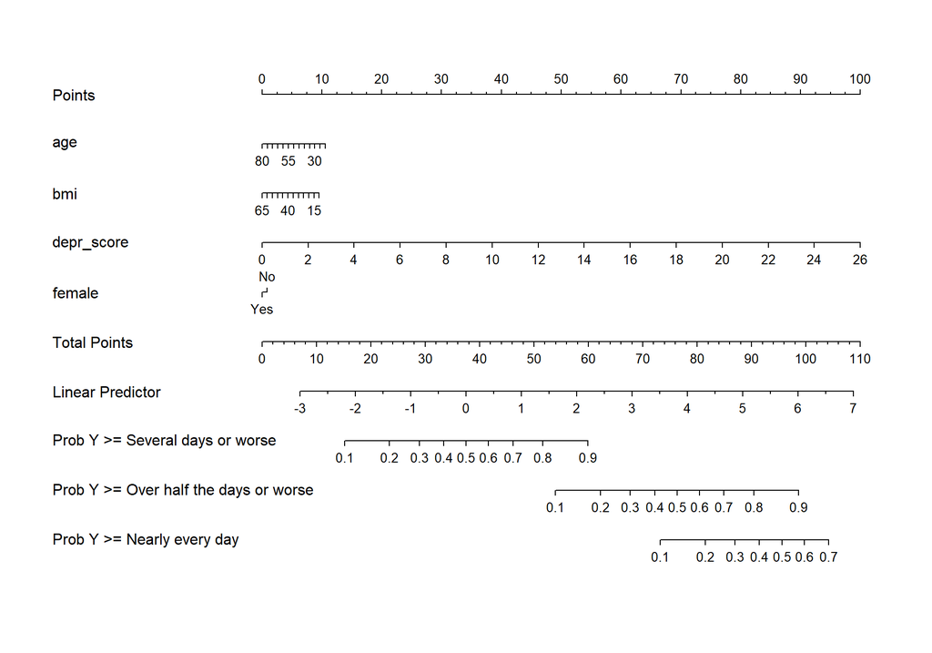

```r
fun.ge3 <- function(x) plogis(x - lrm_2$coef[1] + lrm_2$coef[2])
fun.ge4 <- function(x) plogis(x - lrm_2$coef[1] + lrm_2$coef[3])

plot(nomogram(lrm_2, fun=list('Prob Y >= Several days or worse' = plogis,
                               'Prob Y >= Over half the days or worse' = fun.ge3,
                               'Prob Y >= Nearly every day' = fun.ge4)))
```

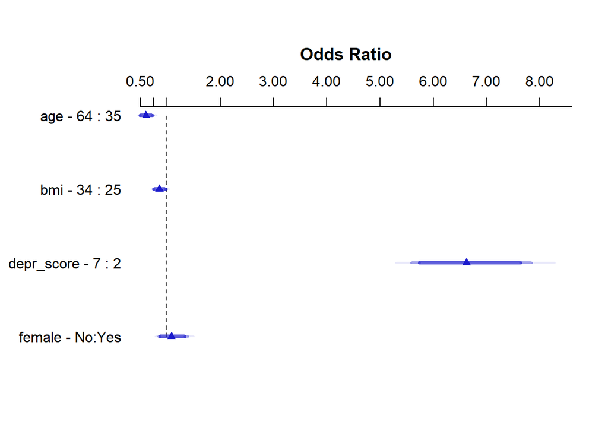

```r
plot(summary(lrm_2))
```

Both of our plots show just how much of a effect the `depr_score` is having compared to the other variables. The `female` variable is having practically no effect, not even showing a separation between categories in the nomogram. `age` and `bmi` are having a small effect, but `depr_score`’s effect completely overshadows all other variables.

# 7 Conclusions and Discussion

## 7.1 Answering My Research Questions

My research question for Analysis 1 was:

> How well can you predict a subject’s score on the PHQ-9 depression screening using their age, sex, average hours of sleep, average minutes of moderate activity, average number of alcoholic drinks consumed, and diabetes diagnosis in a sample of 2000 adults from NHANES 2021-2023?

After my analysis, I would say not very well. The R<sup>2</sup> was quite low and the mean absolute error of 3.348 points would be enough to put a patient into a different depression severity category. I think the more interesting question is what did our effect sizes look like for all our predictors, so we can explore what factors might cause a higher depression screening score. For example, my model predicts that, holding all other variables constant, that women will have depression scores approximately 18% higher then men. This could be explained by the higher percentage of women diagnosed with depression, or maybe there is more to be examined there about the relationship between depression severity and sex. I think one of my biggest limitations was the lack of zeros in my data, due to how I filtered it. This created issues when fitting both our models because there were so many errors created just by the models wanting to predict zeroes when there wasn’t any.

My research question for Analysis 2 was:

> What variables have the largest effect size when predicting a subject’s level of ability to function due to depressive symptoms using their age, sex, BMI, and PHQ-9 depression score in a sample of 2000 adults from NHANES 2021-2023?

The depression screening score by far has the largest effect size, with a 5 point increase in depression screening score being associated with about a 6.5 times increased odds of falling into a more severe depression functioning category. The sex variable had no meaningful effect, and both age and BMI had very minimal effects. However, the predictive results of the model were promising, with a high C statistic and decent accuracy. I think I was limited here by my choice of variables, and maybe I should have chosen more specific variables that I knew impacted functional impairment in depression, instead of the pretty generic demographic information I ended up choosing.

## 7.2 Next Steps

For Analysis 1, I think there is a lot I could do better. First, I would isolate the data set for Analysis 1, so we are not filtering out all the zeros. This would hopefully let the models fit better, or allow me to explore zero-inflated or hurdle models. I would also re-frame my research question to focus on explanatory analysis, as I think it would be more interesting and probably more useful clinically to see what factors might be related to a high depression screening score.

For Analysis 2, I would also re-frame the research question to focus on prediction over effect size, essentially switching the questions I ask about each outcome. While I was happy with seeing how much of an impact the depression screening score had on the depression functioning category, it isn’t exactly exciting or surprising. Since our other variables didn’t have much of an impact, the results ended up feeling very obvious. I think the predictive power of this model was far more interesting, and might be more helpful clinically to predict how well a person might function using their depression screening score. Some new variables, focused specifically on functional impairment in depression, rather than depression symptoms, might improve the model’s prediction ability and clinical importance as well.

The project made me realize how important it is to have a statistician working on a project from the start. Though I picked predictors that were related to depression risk factors, my first model did not perform as well as I would have liked. If this were my own research instead of a publicly available data set, the questions, and thus predictors, could have been created with my specific statistical analysis in mind. I also got a really good feel for the process of doing statistical analysis, and I am at the point where I am truly understand that a majority of the work is just cleaning the data and the analysis tends to be very quick once the data work is done.

# 8 References and Acknowledgments

## 8.1 References

1. NHANES data files for 2021-2023 can be found at https://wwwn.cdc.gov/nchs/nhanes/continuousnhanes/default.aspx?Cycle=2021-2023
2. The depression fact sheet I used to develop my predictors, from the National Institute of Mental Health, can be found here https://www.nimh.nih.gov/health/publications/depression

## 8.2 Acknowledgments

Thank you Dr. Love for two great semesters of statistics, I have learned so much from you. Thank you to my family for listening to me talk about my project work even though they probably didn’t understand fully.

# 9 Use of AI

AI supported the development of this project through R Studio’s spell-check and its help with filling in the details of R functions. I also used AI search results for quick reference or pointing me to the correct websites when Googling.